# LifeAlgorithmShootout

## Life Algorithm Shootout

This document presents the results of comparing a number of algorithms to run the Game of Life on a CPU.

Results are from a 2013 Macbook Pro with a 2.8GHz i7 (that supports AVX2). Results are for 120-second runs of each algorithm. For the hashlife algorithms I gave each 8GB of memory to work with.

Probably any of these results could be improved by unrolling loops and/or making other improvements; I tried to write fairly straightforward code for each. I am also including results for Golly's hlife and qlife and Adam Goucher's lifelib and ulifelib.

These results should be taken with a grain of salt; some of these algorithms have been written to be more general (qlife and hlife), some have extra overhead to maintain history information (lifelib and ulifelib). All these results are with a single CPU core; use of multiple cores would improve the results for some algorithms.

All the plots are cumulative generations per second on the y axis, and generation count on the x axis. All algorithms were terminated after about 120 seconds.

The first two patterns evaluated are large rectangular patterns so we can include the algorithms that only support finite universes (we allow gliders to hit the edge and turn into blocks for the limited universe algorithms). All subsequent patterns we run only on the algorithms that support unbounded grids.

All the code can be found on https://github.com/rokicki/lifealg

```python
import numpy as np
```

```python
import pandas as pd
```

```python
import math
```

```python
filename = '/Users/rokicki/work/lifealg/makedat120.csv'
```

```python
%matplotlib inline
```

```python
import matplotlib.pyplot as plt
```

```python
dat = pd.read_csv(filename)
```

```python
def getoff(s):
    if s in offsets:
        return -offsets[s]
    else:
        return 0
def getmoff(s):
    if s in offsets:
        return 10.**(-offsets[s])
    else:
        return 1
showset = ['array4','lookup','lookup4','qlife','hlife','lifelib','ulifelib','list8x8','list16x16','sse3','avx23',
           'nybble','list16x16','tree','list3','bitpar3']
def plotme(pat, title, q):
    dat['lograte'] = dat.apply(lambda r: math.log(r.gen/r.tim, 10.), axis=1)
    dat['rate'] = dat.apply(lambda r: r.gen/r.tim, axis=1)
    fig, ax = plt.subplots(figsize=[20,10])
    dat2 = dat.loc[dat['algo'].isin(showset)].query('pat=="{0}"'.format(pat)).query(q).groupby('algo')
    plt.loglog()
    for key, group in dat2:
       group.plot(x='gen', y='rate', marker='o', ax=ax, label=key)
       plt.text(group[-1:].gen*1.1, group[-1:].rate*getmoff(key), key, color=ax.legend().get_lines()[-1].get_color())
    plt.title(title)
```

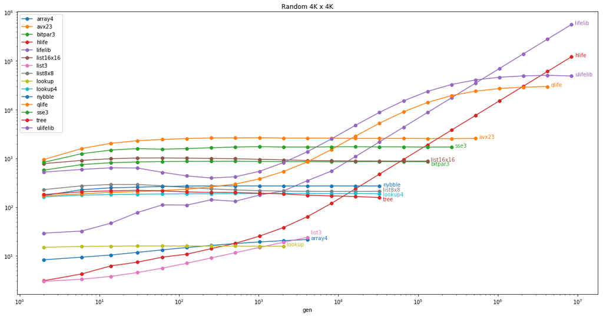

```python
offsets = {'lookup4':0.05,'tree':0.07,'list3':-0.07,'bitpar3':0.08}
plotme('r4kx4k', 'Random 4K x 4K', 'gen<16000000')
```

This is for a very large random initial pattern starting at 30% density. Most algorithms are fairly flat, not taking advantage of stability or period-2 oscillation. Both axes are logarithmic. Lifelib starts slow but runs away quickly due to efficient 16x16 AVX2-based leaf cells; hlife gets there too but more slowly due to a less efficient but more general leaf generation procedure. Both ulifelib and qlife start slowly but start taking advantage of stability and period 2 oscilation about generation 500. Of the brute force algorithms that don't try to be smart, avx23 is best (not surprisingly) with its fixed universe size but list16x16 isn't too far behind. Note the vast size of the y-axis.

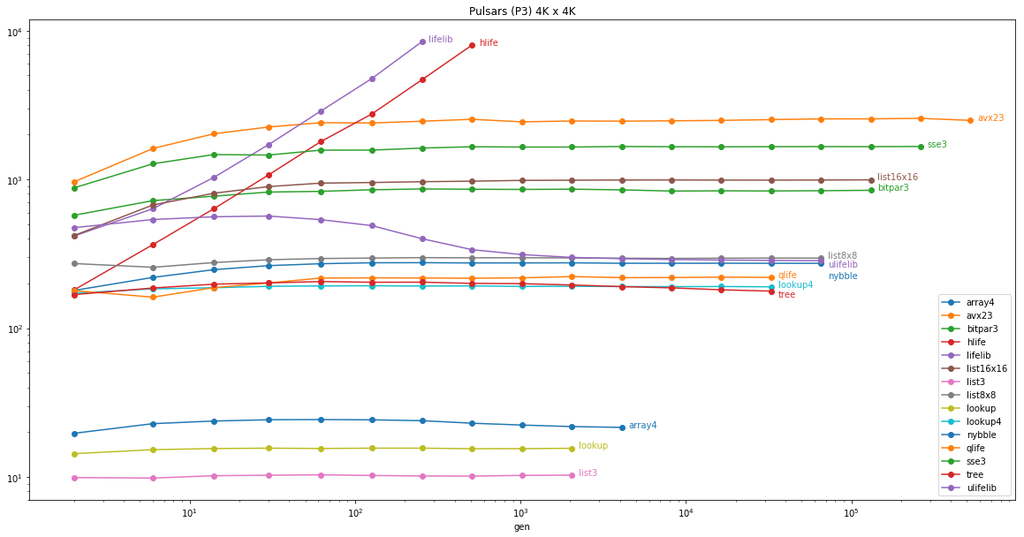

```python
offsets = {'ulifelib':0.04,'nybble':0.1,'tree':0.04}
plotme('bp4kx4k', 'Pulsars (P3) 4K x 4K', 'lograte<4')
```

This pattern is a 4K x 4K (in bits) array of period-3 pulsars; we use period-3 pulsars because none of the algorithms optimize specifically for period-3 oscillators because they are rare. This lets us compare the brute force efficiency of qlife and ulifelib when the universe is not dominated by still lifes and period-2 oscillators. Ulifelib starts out pretty strong but apparently slows down after a bit for some reason, but it is still somewhat faster than qlife. In both cases of course the hashlife-based algorithms hlife and lifelib run away quickly.

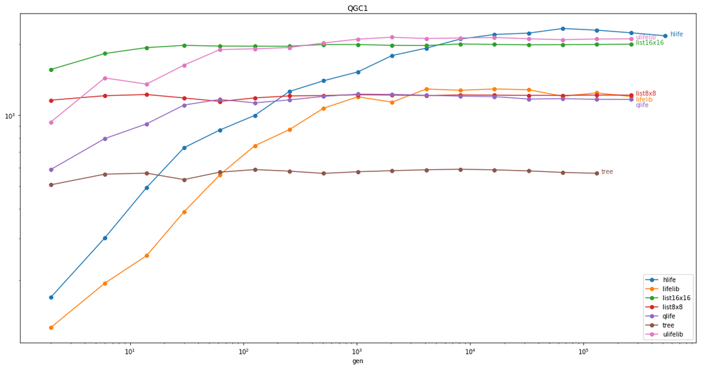

```python
offsets = {'ulifelib':0,'hlife':0,'qlife':0.03,'lifelib':0.02}
plotme('QGC1', 'QGC1', 'lograte<10')
```

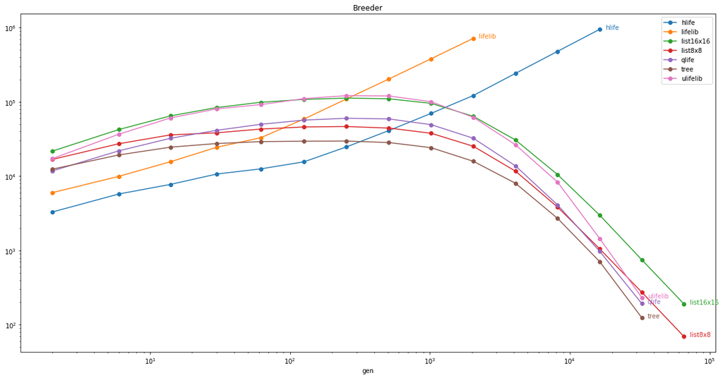

```python
offsets = {}
plotme('breeder', 'Breeder', 'lograte<6.1')
```

The breeder pattern grows quadratically, so runtime of algorithms that do not detect patterns is cubic; that's why almost all the algorithms drop dramatically as the generation count increases. Both hashlife algorithms easily run away, with lifelib doing it much faster.

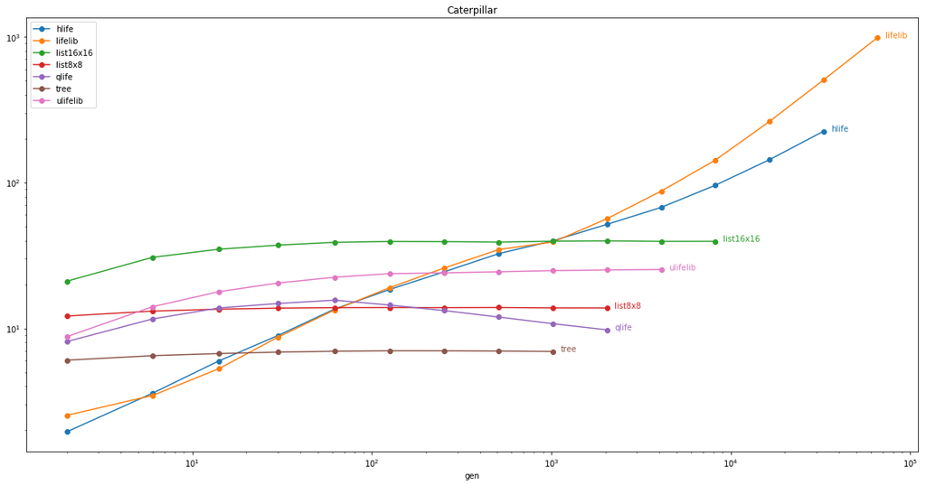

```python
offsets = {}
plotme('caterpillar', 'Caterpillar', 'lograte<3')
```

Caterpillar is a huge slow spaceship. For this particular spaceship, both hash algorithms run away (with 8GB of RAM) but here lifelib beats hlife. Brute-force list16x16 does very well before being overtaken by hlife; list16x16 beats ulifelib handily, and ulifelib beats qlife handily. For this pattern qlife appears to slow down a bit after a while.

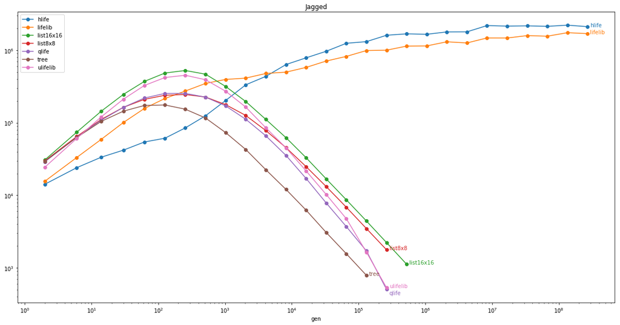

```python
offsets = {'qlife':0.07}
plotme('jagged', 'Jagged', 'lograte<7')
```

Jagged is a linear-growth pattern that shows some interesting and perhaps surprising curved lines; due to the growth, the non-hashlife algorithms slow as the generation count goes up. Hlife and lifelib are close, while ulifelib and qlife are in a near dead-heat.

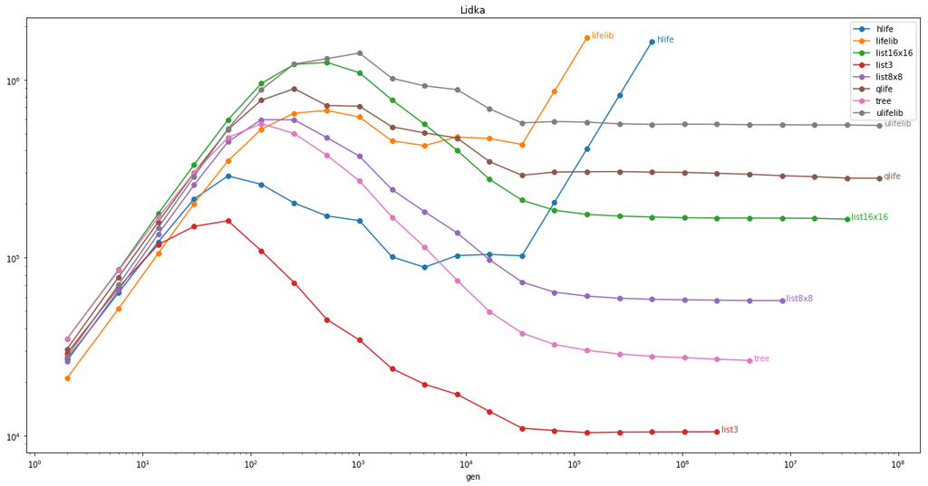

```python
offsets = {}
plotme('lidka', 'Lidka', 'lograte<6.3 and lograte>3.5')
```

Running Lidka for 120 seconds is silly as it quickly stabilizes after about 30,000 generations, at which point both hashlife-based algorithms run away, with lifelib running faster than hlife. For the other algorithms, ulifelib is far in the lead, followed by qlife, and then list16x16.

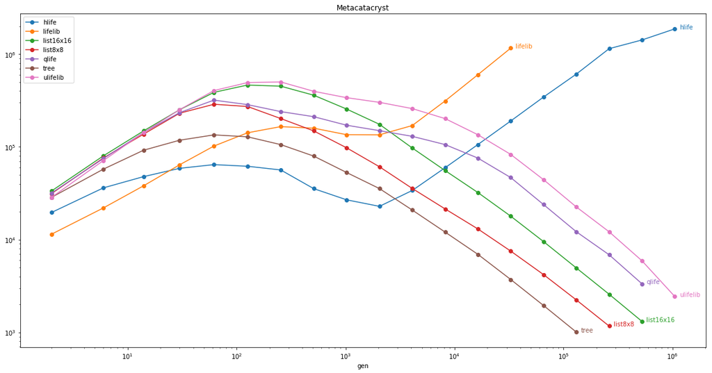

```python
offsets = {}
plotme('mcc', 'Metacatacryst', 'lograte<6.3')
```

Metacatacryst is a tiny quadratic-growth pattern, and so the non-hashlife algorithms slow down as the generation count increases, but ulifelib does very well, followed by qlife. Of the two hash-based algorithms, lifelib does better. Note that the hashlife algorithms do increase in speed as the generation count increases, but they never fully run away on this pattern (even after many days of computation).

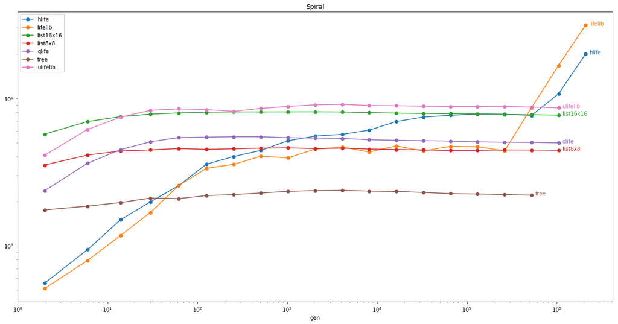

```python
offsets = {}
plotme('spiral', 'Spiral', 'lograte<4.5')
```

Spiral is another pattern with glider streams that run parallel but in different directions, but it is significantly smaller than QGC1. Both hashlife-based algorithms ultimately take off, with hlife in the lead before that, and lifelib in the lead afterwards. The ulifelib and list16x16 algorithms perform well; qlife is behind but not by too much.

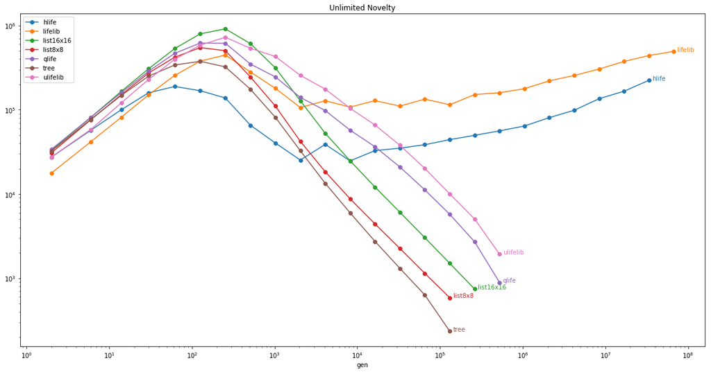

```python
offsets = {}
plotme('unlim', 'Unlimited Novelty', 'lograte<6.3')
```

Unlimited Novelty is a pattern where two rakes at right angles shoot gliders at the debris and this generates chaos. It also is a pattern that grows with generations, so the traditional algorithms slow down. The hashlife algorithms speed up slightly, but only slightly, as time goes on. Lifelib handily beats out hlife, and ulifelib beats both qlife and list16x16, for this pattern.